# 42-naivebayes-modeling

In this notebook, we use Naive Bayes to perform modeling. Our general approach will be to use hyperparameter tuning via cross-validation to identify the best performing hyperparameters, In another notebook, we will investigate the performance of the model.

### 0.0.1 Useful packages

Here, we define the specs for the feature engineering, the model, the generalized workflow, and the parameters that we’ll tune using parameters selected from a max entropy grid. For the Naive Bayes model, the general usemodels template code was not supported but using the naivebayes package model allowed for easy 1:1 translation

```r
nb_recipe <-
  recipe(formula = particle_class ~ ., data = train_data) %>%
  update_role(id, img_id, starts_with('filter'), hash, new_role='no_model') %>%
  step_zv(all_predictors()) %>%
  step_normalize(all_predictors(), -all_nominal())

nb_spec <-
  naive_Bayes(smoothness = tune(), Laplace = tune() ) %>%
  set_mode("classification") %>%
  set_engine("naivebayes")

nb_workflow <-
  workflow() %>%
  add_recipe(nb_recipe) %>%
  add_model(nb_spec)

nb_parameters <- parameters(nb_spec)
nb_grid <- grid_max_entropy(nb_parameters, size=20)
```

# 1 Hyperparameter tuning (model selection) via cross-validation

## 1.1 Cross-validation metric distributions

In this section, we’re going to take a little bit of a look at the individualized performance of the models taking into each fold into account. This will satisfy our academic curiosity in terms of machine learning and also provide some insight into the behaviors of the models. We’ll look more at the aggregated measures in a moment.

We’ll first decompress the tuning metrics a bit to get them into a more friendly form for processing.

```r
#extract the cross validation metrics for the naive bayes model by fold (i.e., unsummarized)
nb_fold_metrics <- nb_tune %>%
  dplyr::select(id, .metrics, .notes) %>%
  unnest(.metrics)

head(nb_fold_metrics, 10)
```

| id | smoothness | Laplace | .metric | .estimator | .estimate | .config | .notes |
| --- | --- | --- | --- | --- | --- | --- | --- |
| Fold1 | 0.8674561 | 2.9964585 | accuracy | binary | 0.9152190 | Preprocessor1_Model01 |  |
| Fold1 | 0.8674561 | 2.9964585 | sens | binary | 0.4824017 | Preprocessor1_Model01 |  |
| Fold1 | 0.8674561 | 2.9964585 | spec | binary | 0.9486564 | Preprocessor1_Model01 |  |
| Fold1 | 0.8674561 | 2.9964585 | ppv | binary | 0.4205776 | Preprocessor1_Model01 |  |
| Fold1 | 0.8674561 | 2.9964585 | npv | binary | 0.9595535 | Preprocessor1_Model01 |  |
| Fold1 | 0.8674561 | 2.9964585 | f_meas | binary | 0.4493732 | Preprocessor1_Model01 |  |
| Fold1 | 0.8674561 | 2.9964585 | roc_auc | binary | 0.7893774 | Preprocessor1_Model01 |  |
| Fold1 | 0.8674561 | 2.9964585 | pr_auc | binary | 0.3815435 | Preprocessor1_Model01 |  |
| Fold1 | 1.2898377 | 0.6600338 | accuracy | binary | 0.9144766 | Preprocessor1_Model02 |  |
| Fold1 | 1.2898377 | 0.6600338 | sens | binary | 0.4761905 | Preprocessor1_Model02 |  |

Now, let’s visualize this generalized performance over all the models

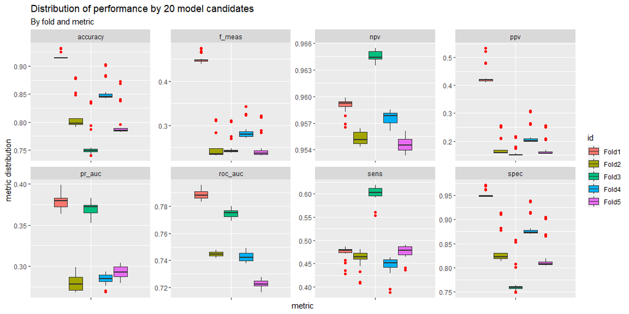

```r
nb_fold_metrics %>%
  mutate(facet_val = if_else(.metric== 'roc_auc' | .metric=='pr_auc' | .metric=='f_meas', 'Aggregate metrics', 'Confusion matrix metrics')) %>%
  ggplot(aes(x=.metric, y=.estimate, fill=id)) +
  geom_boxplot(outlier.colour = 'red', na.rm=TRUE) +
  facet_wrap(facet='.metric', scales='free', nrow=2) +
  labs(title='Distribution of performance by 20 model candidates',
       subtitle='By fold and metric',
       x='metric',
       y='metric distribution') +
  scale_x_discrete(labels=NULL)
```

# 2 Identifying the “best” model

Now, let’s collect the metrics to see how the model did over all of the folds and all of the metrics in order to identify the best model from these candidates. Note that this table looks similar to the prior tibble; the main difference here is that the results are aggregated over the folds (hence the `mean` and `n` columns).

```r
tune_metrics <- nb_tune %>%
  collect_metrics()

head(tune_metrics, 5)
```

| smoothness | Laplace | .metric | .estimator | mean | n | std_err | .config |
| --- | --- | --- | --- | --- | --- | --- | --- |
| 0.8674561 | 2.996459 | accuracy | binary | 0.8195451 | 5 | 0.029290050 | Preprocessor1_Model01 |
| 0.8674561 | 2.996459 | f_meas | binary | 0.2923246 | 5 | 0.039996271 | Preprocessor1_Model01 |
| 0.8674561 | 2.996459 | npv | binary | 0.9587647 | 5 | 0.001814415 | Preprocessor1_Model01 |
| 0.8674561 | 2.996459 | ppv | binary | 0.2205571 | 5 | 0.050853908 | Preprocessor1_Model01 |
| 0.8674561 | 2.996459 | pr_auc | binary | 0.3258485 | 5 | 0.021566739 | Preprocessor1_Model01 |

## 2.1 Basic performance overview

Let’s just look at the overall (fold-less) distribution of the metrics.

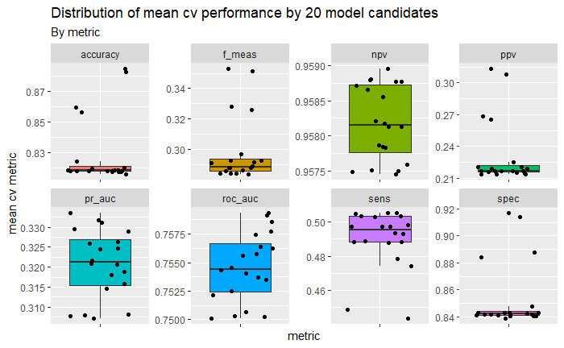

```r
tune_metrics %>%
  ggplot(aes(x=.metric, y=mean)) +
  geom_boxplot(aes(fill=.metric), outlier.shape=NA, na.rm=TRUE) +
  geom_jitter(na.rm=TRUE) +
  facet_wrap(facets='.metric', nrow=2, scales='free') +
  theme(legend.position = 'none') +
  labs(title='Distribution of mean cv performance by 20 model candidates',
       subtitle='By metric',
       x='metric',
       y='mean cv metric') +
  scale_x_discrete(labels=NULL)
```

## 2.2 Making sense of the hyperparameters and their influence

Let’s visualize this so we can make some sort of sense out of it.

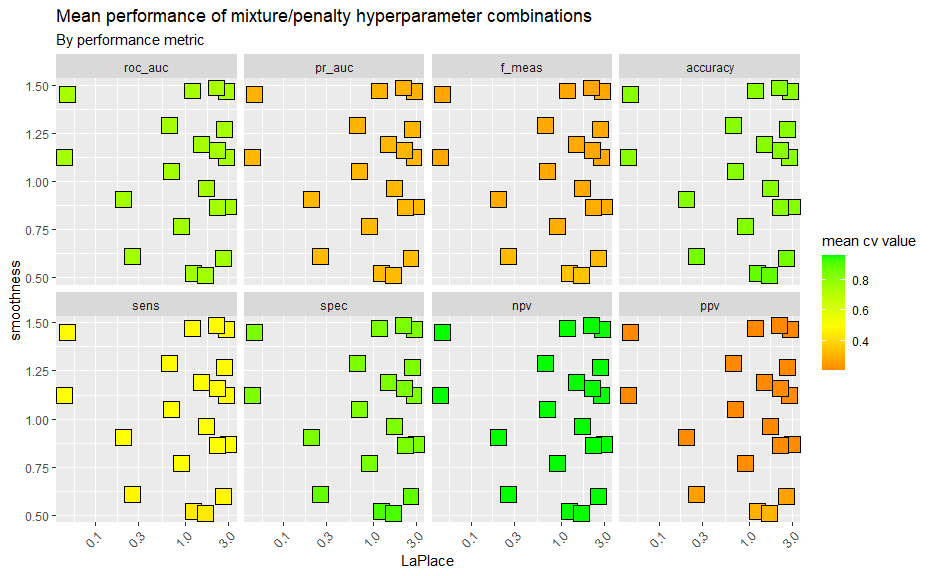

```r
tune_metrics %>%
  mutate(.metric=fct_relevel(.metric, 'roc_auc', 'pr_auc', 'f_meas', 'accuracy', 'sens', 'spec')) %>%
  ggplot(aes(x=Laplace, y=smoothness)) +
  geom_point(aes(fill=mean), shape=22, size=6) +
  scale_x_log10(guide=guide_axis(angle=45)) +
  facet_wrap(ncol=4, facet='.metric') +
  scale_fill_gradient2(low='red', mid='yellow', high='green', midpoint=0.5) +
  labs(title='Mean performance of mixture/penalty hyperparameter combinations',
       subtitle='By performance metric',
         x='LaPlace',
         y='smoothness',
         fill='mean cv value')
```

Here is a difficult-to-understand plot. The objective of this visualization is to begin to digest the relationship between the two hyperparameters and the performance given a certain metric. Recall that hyperparameter tuning evaluates all combinations of hyperparameters. These combos are shown as a square on a particular “subplot” of a metric of interest. Then, there are 20 squares since there are 20 models. And, the arrangement of all the “intersection” squares is identical.

What is of interest here is the color of the squares. Red indicates that the performance is poor, and green indicates that the performance is great. What is interesting here is that all of the squares within a given graph typically had the same color no matter the value of our two hyperparameters. This may suggest these hyperparameters don’t affect the cv value as much as the model itself does in terms of classification.

## 2.3 Looking at all of the metrics together to select a model

One possible way of evaluating a good model might be to rank the model according to its performance across all of the metrics. This allows us to get a bit away from the values themselves. However, we can also look at the values themselves and investigate the relationship.

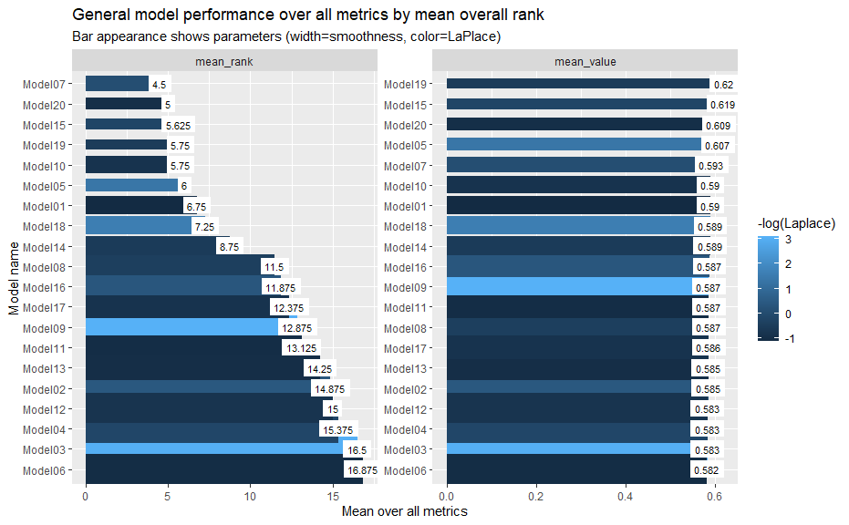

```r
#calculate mean metrics and rank
mdl_overall <- tune_metrics %>%
  group_by(.metric) %>%
  mutate(metr_rank=rank(-mean, ties.method='average')) %>% #-mean so that rank increases (so, worse) with decreasing metric
  group_by(.config, .add=FALSE) %>%
  mutate(mean_rank = mean(metr_rank)) %>% #add mean rank
  mutate(mean_value = -mean(mean, na.rm=TRUE)) %>% #add mean value
  pivot_longer(cols=c(mean_rank, mean_value), names_to = 'agg_perf_type', values_to='agg_perf') %>%
  group_by(agg_perf_type) %>%
  filter(.metric=='pr_auc') #just pick one set of values; all these aggregated values will be identical

#plot; note that there is manipulation of negatives for the directionality and absolute value
mdl_overall %>%
  ggplot(aes(x=reorder_within(str_remove(.config, 'Preprocessor1_'), -agg_perf, agg_perf_type),
             y=abs(agg_perf),
             width=smoothness)) +
  geom_col(aes(fill=-log(Laplace))) +
  geom_label(aes(label=round(abs(agg_perf),3)), label.r=unit(0.0, "lines"), label.size=0, size=3) +
  facet_wrap(~agg_perf_type, ncol=2, scales='free') +
  scale_x_reordered() +
  coord_flip() +
  labs(title='General model performance over all metrics by mean overall rank',
       subtitle='Bar appearance shows parameters (width=smoothness, color=LaPlace)',
       y='Mean over all metrics',
       x='Model name')
```

## 2.4 Selecting the best model

With this information in mind as well as more help from tidymodels, we can then select the “best” model. One way to do this is to simply choose according to some metric. We’ll decide to use `pr_auc` here just because our training data is so imbalanced.

```r
eval_metric <- 'pr_auc'

#show best parameters in terms of pr_auc
nb_tune %>% show_best(eval_metric)
```

| smoothness | Laplace | .metric | .estimator | mean | n | std_err | .config |
| --- | --- | --- | --- | --- | --- | --- | --- |
| 0.5981492 | 2.5942681 | pr_auc | binary | 0.3335970 | 5 | 0.02282279 | Preprocessor1_Model20 |
| 0.5209694 | 1.2254506 | pr_auc | binary | 0.3318298 | 5 | 0.02284614 | Preprocessor1_Model15 |
| 0.5099078 | 1.6557538 | pr_auc | binary | 0.3311769 | 5 | 0.02283993 | Preprocessor1_Model19 |
| 0.6102825 | 0.2579886 | pr_auc | binary | 0.3296037 | 5 | 0.02265186 | Preprocessor1_Model05 |
| 0.7682092 | 0.9006174 | pr_auc | binary | 0.3289718 | 5 | 0.02093987 | Preprocessor1_Model07 |

```r
#select best parameters
best_nb_params <- nb_tune %>%
  select_best(eval_metric)

#show selected parameters
best_nb_params
```

| smoothness | Laplace | .config |
| --- | --- | --- |
| 0.5981492 | 2.594268 | Preprocessor1_Model20 |

# 3 Training fit

Having identified the best hyperparameters, we can create the final fit on all of the training data:

```r
#finalize workflow with model hyperparameters
nb_final_wf <- nb_workflow %>%
  finalize_workflow(best_nb_params)
nb_final_wf
```

```
== Workflow =============================================================================================================================
Preprocessor: Recipe
Model: naive_Bayes()

-- Preprocessor -------------------------------------------------------------------------------------------------------------------------
2 Recipe Steps

* step_zv()
* step_normalize()

-- Model --------------------------------------------------------------------------------------------------------------------------------
Naive Bayes Model Specification (classification)

Main Arguments:
  smoothness = 0.598149206023663
  Laplace = 2.59426813409664

Computational engine: naivebayes
```

```r
#using final workflow, fit on training data
nb_final_fit <- nb_final_wf %>%
  fit(data = train_data)
```

# 4 Save markdown file

```r
fs::file_copy('42-naive-bayes-modeling.nb.html', './html_results/42-naive-bayes-modeling.nb.html', overwrite=TRUE)
```

[output not shown]

```r
#move_model_info('nb', 'save')
```